# mixOmics with caret examples

Jonathan Thorsen

2022-10-26

Vignette written in 2017, small update in 2022.

This is an example of how we can use sparse Partial Least Squares for modelling. The model is implemented in the `mixOmics` package (http://mixomics.org/). The package has some cross-validation functionality but this is not nearly as rich as what the `caret` package offers. But luckily, it can be added to the `caret` ecosystem to take advantage of all these nice features.

This small utility package does just that and can be installed from github using `devtools::install_github("jonathanth/mixOmicsCaret")`

Let’s look at how to use it.

## Setup

First, we load some required packages.

```r
library(mlbench)
data(Sonar)
library(doMC)
library(caret)
library(pROC)
library(mixOmics)
library(tidyverse)
library(mixOmicsCaret)  # This package
options(width = 90)
```

Then we can register doMC for the built-in multithreading in `caret`. A common option is number of threads minus one. On a quad-core with hyperthreading (Macbook Pro i7), that’s 7.

```r
registerDoMC(cores = 7)
```

## Data

We start by examining the dummy data we’ll be using. It’s called Sonar and comes from the `mlbench` package.

```r
head(Sonar)
```

```
##       V1     V2     V3     V4     V5     V6     V7     V8     V9    V10    V11    V12
## 1 0.0200 0.0371 0.0428 0.0207 0.0954 0.0986 0.1539 0.1601 0.3109 0.2111 0.1609 0.1582
## 2 0.0453 0.0523 0.0843 0.0689 0.1183 0.2583 0.2156 0.3481 0.3337 0.2872 0.4918 0.6552
## 3 0.0262 0.0582 0.1099 0.1083 0.0974 0.2280 0.2431 0.3771 0.5598 0.6194 0.6333 0.7060
## 4 0.0100 0.0171 0.0623 0.0205 0.0205 0.0368 0.1098 0.1276 0.0598 0.1264 0.0881 0.1992
## 5 0.0762 0.0666 0.0481 0.0394 0.0590 0.0649 0.1209 0.2467 0.3564 0.4459 0.4152 0.3952
## 6 0.0286 0.0453 0.0277 0.0174 0.0384 0.0990 0.1201 0.1833 0.2105 0.3039 0.2988 0.4250
##      V13    V14    V15    V16    V17    V18    V19    V20    V21    V22    V23    V24
## 1 0.2238 0.0645 0.0660 0.2273 0.3100 0.2999 0.5078 0.4797 0.5783 0.5071 0.4328 0.5550
## 2 0.6919 0.7797 0.7464 0.9444 1.0000 0.8874 0.8024 0.7818 0.5212 0.4052 0.3957 0.3914
## 3 0.5544 0.5320 0.6479 0.6931 0.6759 0.7551 0.8929 0.8619 0.7974 0.6737 0.4293 0.3648
## 4 0.0184 0.2261 0.1729 0.2131 0.0693 0.2281 0.4060 0.3973 0.2741 0.3690 0.5556 0.4846
## 5 0.4256 0.4135 0.4528 0.5326 0.7306 0.6193 0.2032 0.4636 0.4148 0.4292 0.5730 0.5399
## 6 0.6343 0.8198 1.0000 0.9988 0.9508 0.9025 0.7234 0.5122 0.2074 0.3985 0.5890 0.2872
##      V25    V26    V27    V28    V29    V30    V31    V32    V33    V34    V35    V36
```

[output cut: 27 more lines]

```r
Sonar$Class
```

```
##   [1] R R R R R R R R R R R R R R R R R R R R R R R R R R R R R R R R R R R R R R R R R R
##  [43] R R R R R R R R R R R R R R R R R R R R R R R R R R R R R R R R R R R R R R R R R R
##  [85] R R R R R R R R R R R R R M M M M M M M M M M M M M M M M M M M M M M M M M M M M M
## [127] M M M M M M M M M M M M M M M M M M M M M M M M M M M M M M M M M M M M M M M M M M
## [169] M M M M M M M M M M M M M M M M M M M M M M M M M M M M M M M M M M M M M M M M
## Levels: M R
```

```r
dim(Sonar)
```

```
## [1] 208  61
```

Alright, 60 predictors, 208 observations, 2 classes. Let’s partition the data into a training set and a test set.

```r
set.seed(123)
inTraining <- createDataPartition(Sonar$Class, p = .75, list = FALSE)
training <- Sonar[ inTraining,]
testing  <- Sonar[-inTraining,]
```

## Model and cross-validation

Now we will setup a cross validation to see how many predictors we should include. First, let’s set up the options. It will run 5 repeats of 10-fold CV. We will keep the resamples and the predictions, and allow it to run in parallel. We will turn off verbose-mode for now. We save this as a trainControl object, which is just a set of options for `caret`.

```r
repCV10 <- trainControl(method = "repeatedcv",
                        number = 10,
                        repeats = 5,
                        returnResamp = "all",
                        savePredictions = "all",
                        allowParallel = T,
                        verboseIter = F)
```

Now for the CV loop itself. This will take some time. We have asked it to model Class M as a numeric 0/1, which is fine for spls but `caret` throws a warning we can safely ignore. We will try 1 to 5 components, with a range of keepX values. This is the number of predictors allowed per component. Note the `fixX` argument, which is left empty for now. This allows us to manually specify number of predictors per component.

```r
set.seed(123)
SonarPLS <- train(as.numeric(Class == "M") ~ ., data = training,
                  method = get_mixOmics_spls(),
                  preProc = c("center", "scale"),
                  tuneGrid = expand.grid(ncomp = 1:5,
                                         keepX = c(1, 2, 4, 8, 16, 25, 40, 50, 60),
                                         keepY = 1),
                  trControl = repCV10,
                  fixX = c())
```

```
## Warning in train.default(x, y, weights = w, ...): You are trying to do regression and your
## outcome only has two possible values Are you trying to do classification? If so, use a 2
## level factor as your outcome column.
```

Let’s inspect the results!

```r
SonarPLS
```

```
## sparse PLS (mixOmics)
##
## 157 samples
##  60 predictor
##
## Pre-processing: centered (60), scaled (60)
## Resampling: Cross-Validated (10 fold, repeated 5 times)
## Summary of sample sizes: 141, 141, 141, 142, 141, 142, ...
## Resampling results across tuning parameters:
##
##   ncomp  keepX  RMSE       Rsquared   MAE
##   1       1     0.4428918  0.2778487  0.4032228
##   1       2     0.4426901  0.2794088  0.3996691
##   1       4     0.4379582  0.2921246  0.3911516
##   1       8     0.4373480  0.2935882  0.3880929
```

[output cut: 45 more lines]

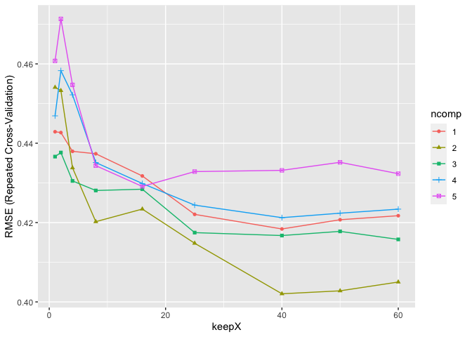

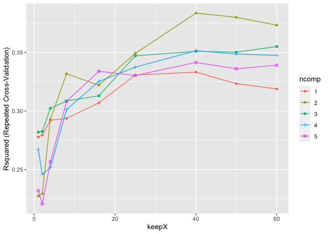

```r
ggplot(SonarPLS, metric = "RMSE")
ggplot(SonarPLS, metric = "Rsquared")
```

We can also manually extract the predictions, calculate AUC, and plot it:

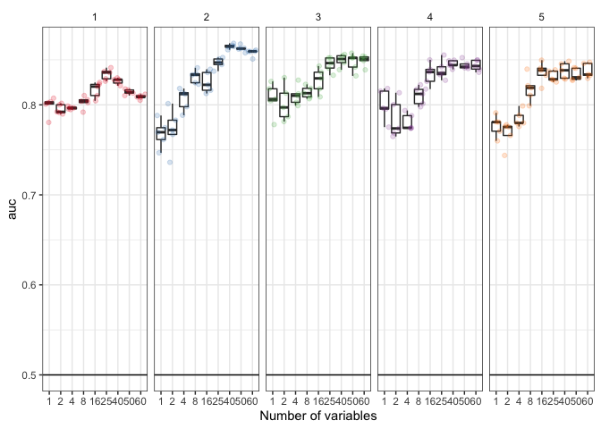

```r
SonarPLS$pred %>%
  separate(Resample, c("Fold", "Rep")) %>%
  group_by(ncomp, keepX, Rep) %>%
  summarize(auc = pROC::auc(predictor = pred, obs, direction = "<") %>% as.numeric) %>%
  ggplot(aes(x = factor(keepX), y = auc)) +
    geom_boxplot(outlier.shape = NA) +
    geom_jitter(aes(color = factor(ncomp)), alpha = 0.2, show.legend = FALSE) +
    geom_hline(yintercept = 0.5) +
    facet_grid(. ~ ncomp) +
    scale_color_brewer(palette = "Set1", name = NULL) +
    theme_bw() + theme(strip.background = element_blank()) +
    xlab("Number of variables")
```

Looks like the first component saturates at 25 predictors. Let’s use the `fixX` parameter to force comp 1 to have 25 predictors and let the following components try out all combinations. This allows us to flexibly set individual parameter numbers for each component. Lets re-run the cross-validation with this option.

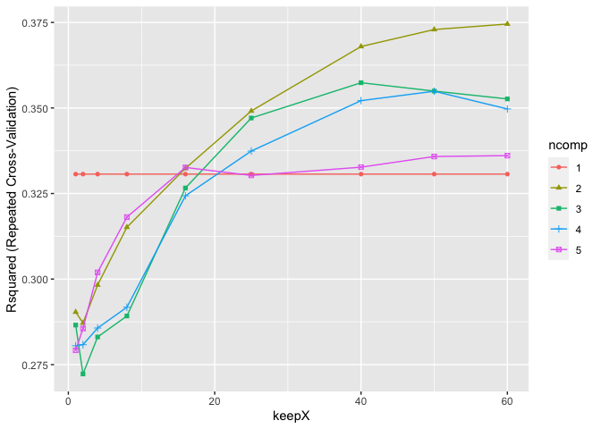

```r
set.seed(123)
SonarPLS <- train(as.numeric(Class == "M") ~ ., data = training,
                  method = get_mixOmics_spls(),
                  preProc = c("center", "scale"),
                  tuneGrid = expand.grid(ncomp = 1:5,
                                         keepX = c(1, 2, 4, 8, 16, 25, 40, 50, 60),
                                         keepY = 1),
                  trControl = repCV10,
                  fixX = c(25))
ggplot(SonarPLS, metric = "Rsquared")
```

Alright, we can do a little bit better if we add another component with 60 variables. But after that, the model starts overfitting and the CV-error increases / Rsquared decreases.

## Evaluate the final model

Looks like we have found our final model! Lets retrieve the predicted values, that we can use for unbiased downstream analyses. We want an average across the repeats to ensure we didn’t just get lucky with the fold divisions. Since we have a test set, we can also look at the test set performance of the final model, using the `predict` function on the `SonarPLS` object with the `testing` dataframe as new data.

```r
# Retrieve the predictions from the optimal model
bestSet <- SonarPLS %>% get_best_predictions %>% group_by(Rep)
head(bestSet)
```

```
## # A tibble: 6 × 8
## # Groups:   Rep [1]
##    pred   obs rowIndex ncomp keepX keepY Fold   Rep
##   <dbl> <dbl>    <int> <int> <dbl> <dbl> <chr>  <chr>
## 1 0.362     0        1     2    60     1 Fold02 Rep1
## 2 1.10      0        2     2    60     1 Fold08 Rep1
## 3 0.332     0        3     2    60     1 Fold05 Rep1
## 4 0.619     0        4     2    60     1 Fold01 Rep1
## 5 0.326     0        5     2    60     1 Fold04 Rep1
## 6 0.585     0        6     2    60     1 Fold09 Rep1
```

```r
bestSet %>%
  summarize(auc = pROC::auc(obs, pred, direction = "<") %>% as.numeric) %>%
  arrange(auc)
```

```
## # A tibble: 5 × 2
##   Rep     auc
##   <chr> <dbl>
## 1 Rep3  0.859
## 2 Rep1  0.860
## 3 Rep4  0.862
## 4 Rep5  0.862
## 5 Rep2  0.868
```

```r
savedPreds <- SonarPLS %>% get_best_predictions %>% filter(Rep == "Rep3")
head(savedPreds)
```

```
##        pred obs rowIndex ncomp keepX keepY   Fold  Rep
## 1 0.2950255   0        1     2    60     1 Fold06 Rep3
## 2 1.2395565   0        2     2    60     1 Fold03 Rep3
## 3 0.2266207   0        3     2    60     1 Fold01 Rep3
## 4 0.6671375   0        4     2    60     1 Fold01 Rep3
## 5 0.3880590   0        5     2    60     1 Fold01 Rep3
## 6 0.5428043   0        6     2    60     1 Fold05 Rep3
```

```r
# Best CV predictions
cvauc <- auc(obs ~ pred, data = savedPreds, direction = "<")
```

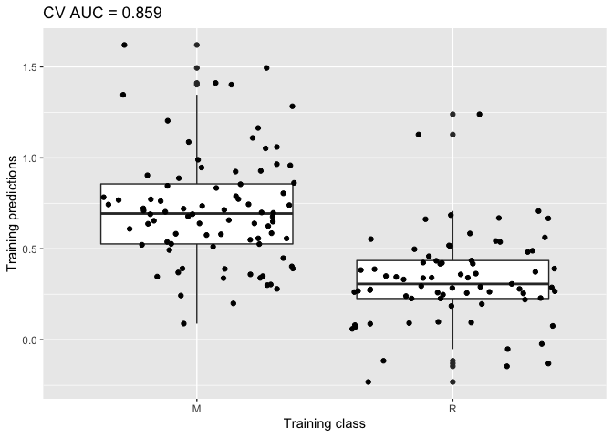

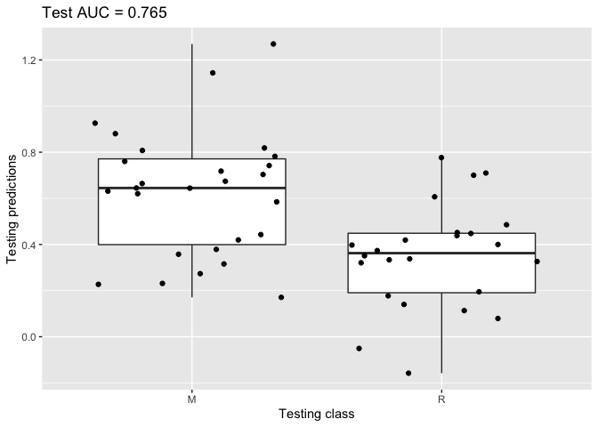

```r
qplot(ifelse(obs == 1, "M", "R"), pred, data = savedPreds, geom = c("boxplot", "jitter")) +
  xlab("Training class") +
  ylab("Training predictions") +
  ggtitle(paste0("CV AUC = ", round(cvauc, 3)))

# Test set predictions
testPreds <- predict(SonarPLS, testing)
cvauc <- auc(predictor = testPreds, testing$Class, direction = ">")
qplot(testing$Class, testPreds, geom = c("boxplot", "jitter")) +
  xlab("Testing class") +
  ylab("Testing predictions") +
  ggtitle(paste0("Test AUC = ", round(cvauc, 3)))
```

We can also run e.g. a logistic regression with these predictions, or use them for other downstream stuff.

```r
# Training (CV)
glm(obs ~ pred, data = savedPreds, family = binomial) %>% summary
```

```
##
## Call:
## glm(formula = obs ~ pred, family = binomial, data = savedPreds)
##
## Deviance Residuals:
##     Min       1Q   Median       3Q      Max
## -2.9731  -0.7594   0.1373   0.7380   2.1659
##
## Coefficients:
##             Estimate Std. Error z value Pr(>|z|)
## (Intercept)  -2.7578     0.5074  -5.435 5.47e-08 ***
## pred          5.7804     0.9754   5.926 3.10e-09 ***
## ---
## Signif. codes:  0 '***' 0.001 '**' 0.01 '*' 0.05 '.' 0.1 ' ' 1
##
## (Dispersion parameter for binomial family taken to be 1)
##
##     Null deviance: 216.88  on 156  degrees of freedom
## Residual deviance: 151.66  on 155  degrees of freedom
## AIC: 155.66
##
## Number of Fisher Scoring iterations: 5
```

```r
# Test
glm(testing$Class == "M" ~ testPreds, family = binomial) %>% summary
```

```
##
## Call:
## glm(formula = testing$Class == "M" ~ testPreds, family = binomial)
##
## Deviance Residuals:
##     Min       1Q   Median       3Q      Max
## -1.8312  -0.9711   0.2897   0.8381   1.7565
##
## Coefficients:
##             Estimate Std. Error z value Pr(>|z|)
## (Intercept)  -2.0826     0.7679  -2.712  0.00669 **
## testPreds     4.5750     1.4825   3.086  0.00203 **
## ---
## Signif. codes:  0 '***' 0.001 '**' 0.01 '*' 0.05 '.' 0.1 ' ' 1
##
## (Dispersion parameter for binomial family taken to be 1)
##
##     Null deviance: 70.524  on 50  degrees of freedom
## Residual deviance: 56.768  on 49  degrees of freedom
## AIC: 60.768
##
## Number of Fisher Scoring iterations: 4
```